# Price Sensitivity and Sales Performance Across Rainoil Retail Outlets: An Exploratory and Inferential Analysis of 2024 Fuel Sales Data

# 6 Technique 2 — Data Visualisation

**Theory recap:** Effective data visualisation applies the grammar of graphics — mapping data attributes to geometric properties (position, colour, size) to reveal patterns that numerical summaries cannot (Adi, 2026, Ch. 5; Wickham, 2016). Chart selection must match the data type and the question being asked.

**Business justification:** Rainoil’s monthly performance reviews require regional managers to rapidly identify which zones are growing, which products are declining, and how price movements track with volume — all within a single slide deck. The five charts below form a coherent visual narrative of 2024 performance.

## 6.1 Monthly PMS Volume Trend by Zone

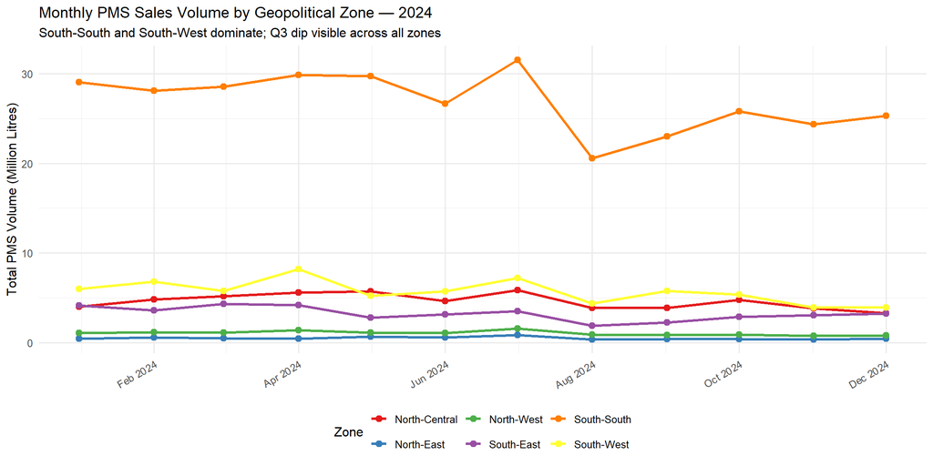

```r
stations_long |>
  group_by(month_date, zone) |>
  summarise(total_pms = sum(pms_vol, na.rm = TRUE) / 1e6, .groups = "drop") |>
  ggplot(aes(x = month_date, y = total_pms, colour = zone, group = zone)) +
  geom_line(linewidth = 1.1) +
  geom_point(size = 2.5) +
  scale_x_date(date_labels = "%b %Y", date_breaks = "2 months") +
  scale_colour_brewer(palette = "Set1") +
  labs(title = "Monthly PMS Sales Volume by Geopolitical Zone — 2024",
       subtitle = "South-South and South-West dominate; Q3 dip visible across all zones",
       x = NULL, y = "Total PMS Volume (Million Litres)", colour = "Zone") +
  theme_minimal(base_size = 12) +
  theme(legend.position = "bottom",
        axis.text.x = element_text(angle = 30, hjust = 1))
```

## 6.2 Boxplot of Monthly PMS Volume by Zone

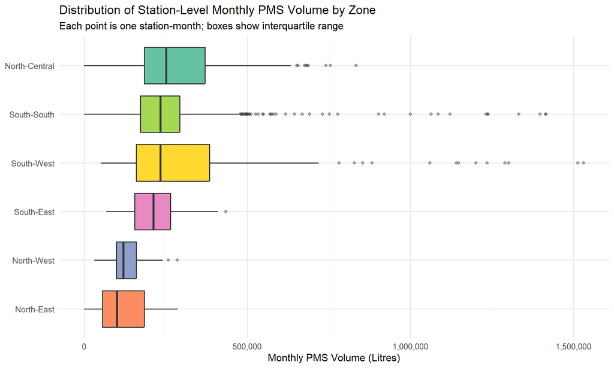

```r
stations_long |>
  filter(!is.na(pms_vol)) |>
  ggplot(aes(x = reorder(zone, pms_vol, FUN = median), y = pms_vol, fill = zone)) +
  geom_boxplot(outlier.alpha = 0.4, outlier.size = 1.5) +
  coord_flip() +
  scale_y_continuous(labels = label_comma()) +
  scale_fill_brewer(palette = "Set2") +
  labs(title = "Distribution of Station-Level Monthly PMS Volume by Zone",
       subtitle = "Each point is one station-month; boxes show interquartile range",
       x = NULL, y = "Monthly PMS Volume (Litres)", fill = "Zone") +
  theme_minimal(base_size = 12) +
  theme(legend.position = "none")
```